# VISUALISASI DATA KATEGORIK

Patricia Pingkan Kumenap

2025-03-09

## 0.1 BAR CHART

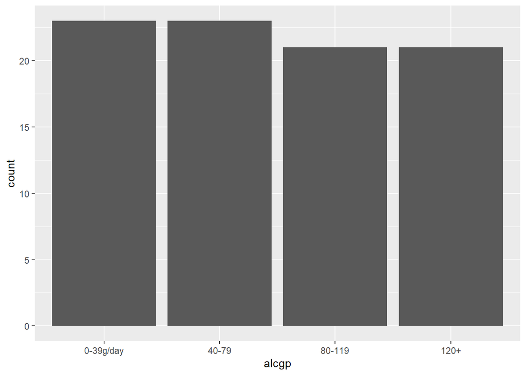

```r
library(ggplot2)
ggplot(data = esoph, mapping = aes(x = alcgp)) +
  geom_bar()
```

Dataset “Esoph” merupakan dataset R Studio yang menyajikan informasi seputar hubungan antara konsumsi alkohol dan konsumsi tembakau dengan kanker esofagus. Dalam hal ini, dataset “Esoph” memiliki beberapa variabel yang meliputi : - egegp : Kelompok Umur - alcgp : Kelompok Konsumsi Alkohol - tobgp : Kelompok Konsumsi Tembakau - ncases : Jumlah Individu yang terdiagnosis kanker esofagus - ncontrols : Jumlah individu dalam kelompok tersebut yang tidak terdiagnosis kanker esofagus.

Data set ini terdiri dari 88 observasi dengan total 5 variabel.

Secara default, geom_bar() menggunakan stat = “count”, yang berarti ia akan menghitung jumlah observasi (frekuensi) untuk setiap kategori dari variabel yang disebutkan pada sumbu x dan menampilkannya sebagai tinggi batang. Namun, ketika Anda menggunakan stat = “identity”, Anda memberitahu ggplot2 untuk menggunakan nilai yang sudah ada di data sebagai tinggi batang, bukan menghitung frekuensi.

## 0.2 BAR CHART DENGAN TABEL FREKUENSI

### 0.2.1 Membuat tabel frekuensi

```r
freqtab <- as.data.frame(table(esoph$alcgp))
freqtab
```

```
##        Var1 Freq
## 1 0-39g/day   23
## 2     40-79   23
## 3    80-119   21
## 4      120+   21
```

### 0.2.2 Membuat Bar Chart

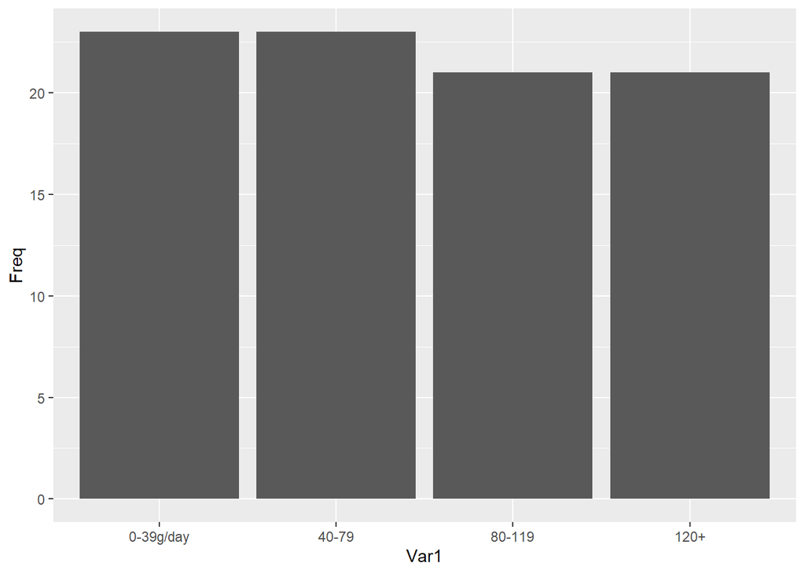

```r
ggplot(data = freqtab, mapping = aes(x = Var1, y = Freq)) +
  geom_bar(stat = "identity")
```

Cara lain yang dapat digunakan untuk membuat diagram batang ketika data yang kita miliki sudah dalam bentuk tabel frekuensi adalah dengan geom_col().

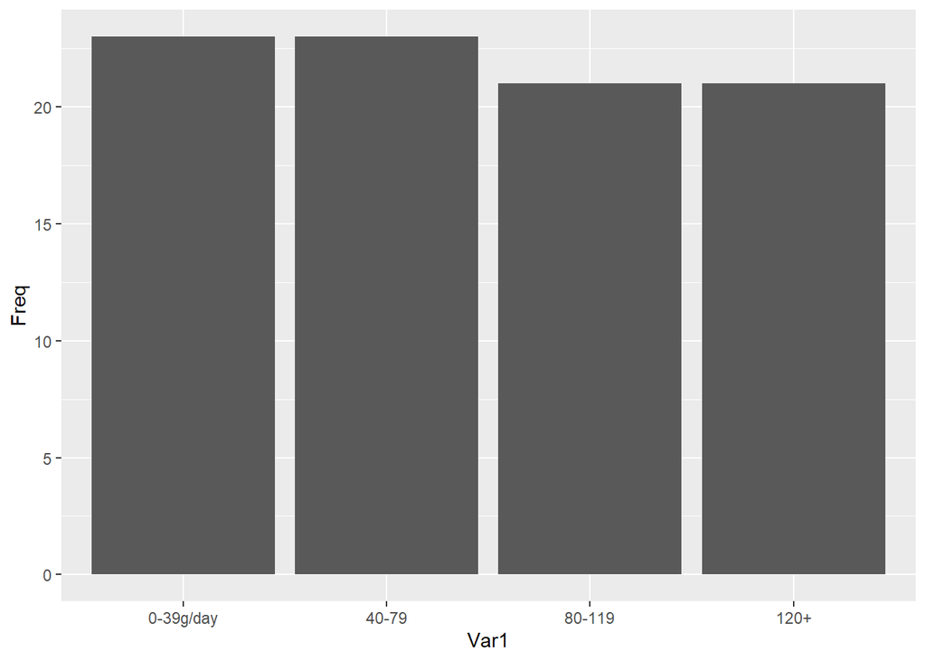

```r
ggplot(data = freqtab, mapping = aes(x = Var1, y = Freq)) +
  geom_col()
```

### 0.2.3 Modifikasi Bar Chart

Menambahkan judul, mewarnai grafik, dan memberikan label pada setiap batang.

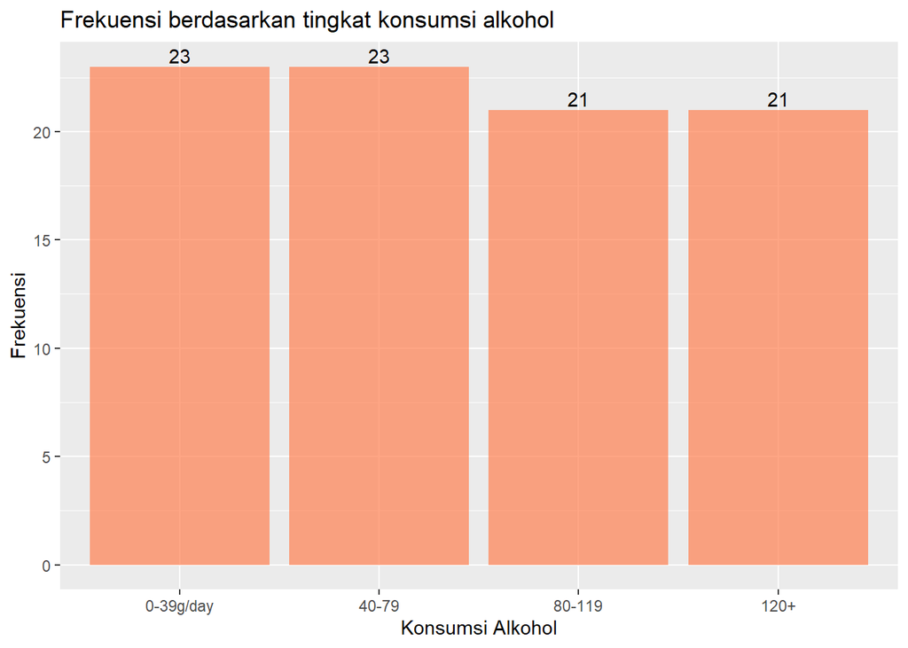

```r
ggplot(data = freqtab, mapping = aes(x = Var1, y = Freq)) +
  geom_col(fill = "coral", alpha = 0.7) +
  labs(title = "Frekuensi berdasarkan tingkat konsumsi alkohol",
       x = "Konsumsi Alkohol",
       y = "Frekuensi") +
  geom_text(aes(label = Freq), vjust = -0.25)
```

## 0.3 GROUPED BAR CHART

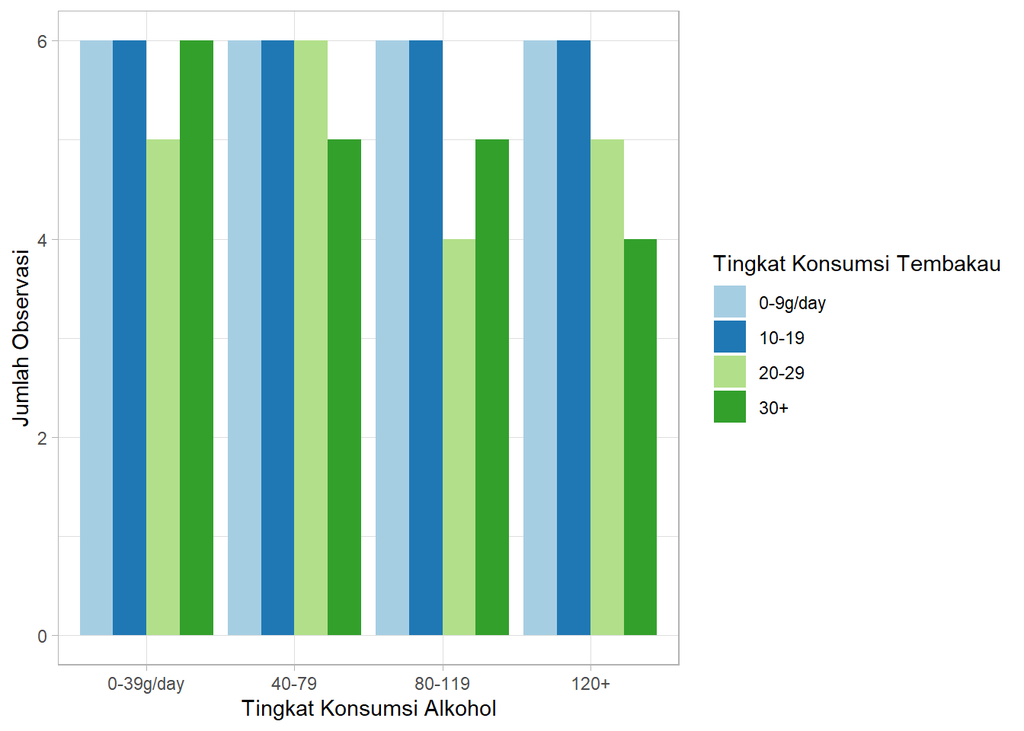

```r
ggplot(data = esoph, mapping=aes(x = alcgp, fill = as.factor(tobgp))) +
  geom_bar(position = "dodge", stat = "count") +
  labs(
    x = "Tingkat Konsumsi Alkohol",
    fill = "Tingkat Konsumsi Tembakau",
    y = "Jumlah Observasi"
  ) +
  scale_fill_brewer(palette = "Paired") +
  theme_light()
```

## 0.4 PIE CHART

Menyiapkan data dengan meringkas menjadi tabel frekuensi

```r
library(dplyr)
df <- esoph %>%
  group_by(alcgp) %>%
  summarise(counts = n())
df
```

```
## # A tibble: 4 × 2
##   alcgp     counts
##   <ord>      <int>
## 1 0-39g/day     23
## 2 40-79         23
## 3 80-119        21
## 4 120+          21
```

Mengitung posisi label teks sebagai jumlah kumulatif proporsi.

```r
df <- df %>%
  arrange(desc(alcgp)) %>%
  mutate(
    prop = round(counts * 100 / sum(counts), 1),
    lab.ypos = cumsum(prop) - 0.5 * prop
  )
head(df, 4)
```

```
## # A tibble: 4 × 4
##   alcgp     counts  prop lab.ypos
##   <ord>      <int> <dbl>    <dbl>
## 1 120+          21  23.9     12.0
## 2 80-119        21  23.9     35.8
## 3 40-79         23  26.1     60.9
## 4 0-39g/day     23  26.1     87.0
```

- arrange(desc(alcgp)) : mengurutkan kategori alhokol dari terbesar ke terkecil
- prop=round(counts * 100 / sum(counts), 1)) : menghitung proporsi setiap kategori dalam presentase
- lab.ypos=cumsum(prop) - 0.5 * prop) : menentukan posisi teks pada pie chart agar berada di tengah-tengah

Membuat grafik Pie Chart

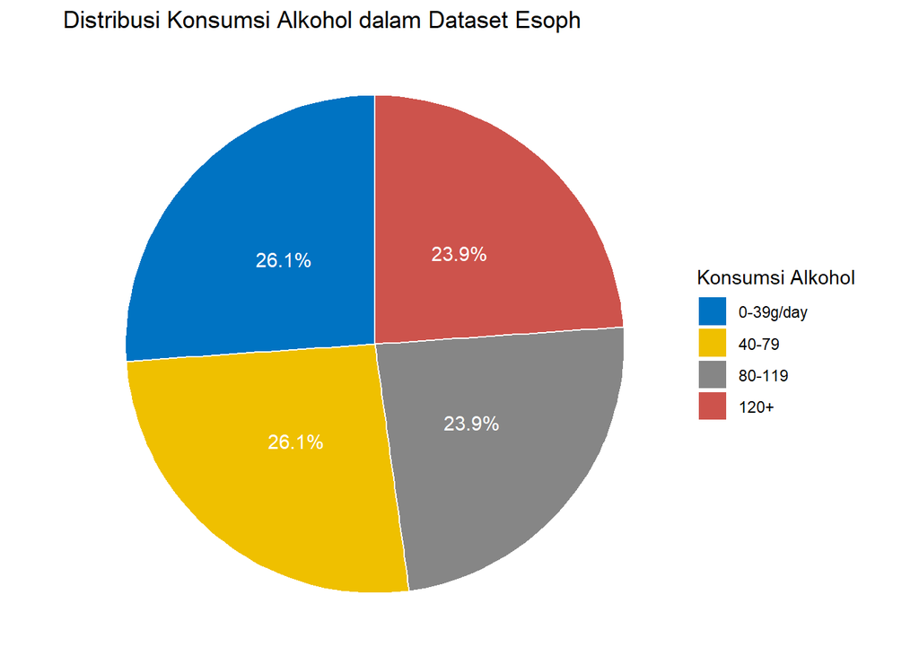

```r
library(ggplot2)
library(ggpubr)
ggplot(df, aes(x = "", y = prop, fill = alcgp)) +
  geom_bar(width = 1, stat = "identity", color = "white") +
  geom_text(aes(y = lab.ypos, label = paste0(prop, "%")), color = "white") +
  coord_polar("y", start = 0) +
  ggpubr::fill_palette("jco") +
  theme_void() +
  labs(fill = "Konsumsi Alkohol", title = "Distribusi Konsumsi Alkohol dalam Dataset Esoph")
```

- geom_bar(width = 1, stat = “identity”, color = “white”) : membuat bar chart dengan warna putih sebagai batas antar bagian - geom_text(aes(y = lab.ypos, label = paste0(prop, “%”)), color = “white”) : menambahkan label presentase pada tiap bagian pie chart - coord_polar(“y”, start = 0) : mengubah bar chart menjadi pie chart - ggpubr::fill_palette(“jco”) : menggunakan palet warna dari ggpubr

## 0.5 NEEDLE CHART

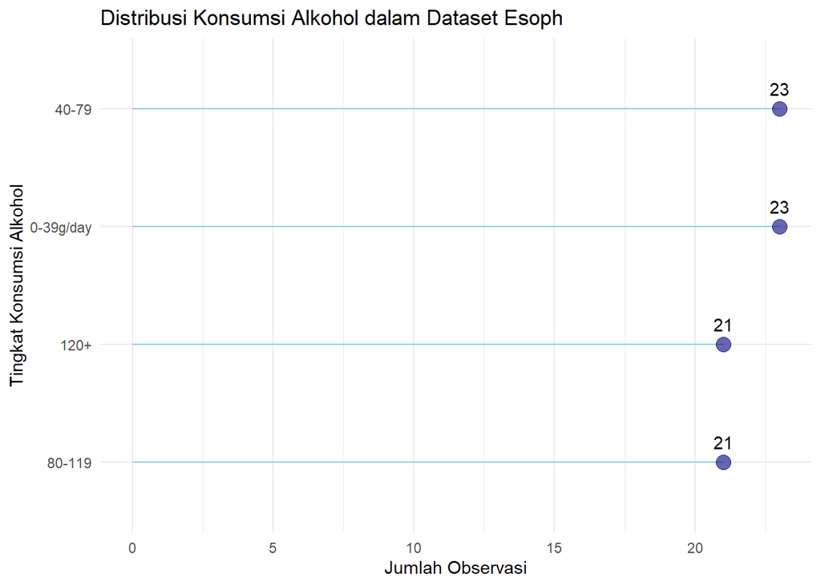

```r
library(ggplot2)
ggplot(data = freqtab, mapping=aes(x = reorder(Var1, Freq), y = Freq)) +
  geom_segment(aes(x = reorder(Var1, Freq),
                   xend = reorder(Var1, Freq),
                   y = 0, yend = Freq),
               color = "skyblue") +
  geom_point(color = "navyblue", size = 4, alpha = 0.6) +
  geom_text(aes(label = Freq), vjust = -1.00) +
  coord_flip() +
  labs(
    y = "Jumlah Observasi",
    x = "Tingkat Konsumsi Alkohol",
    title = "Distribusi Konsumsi Alkohol dalam Dataset Esoph"
  ) +
  theme_minimal()
```

## 0.6 STACKED BAR CHART

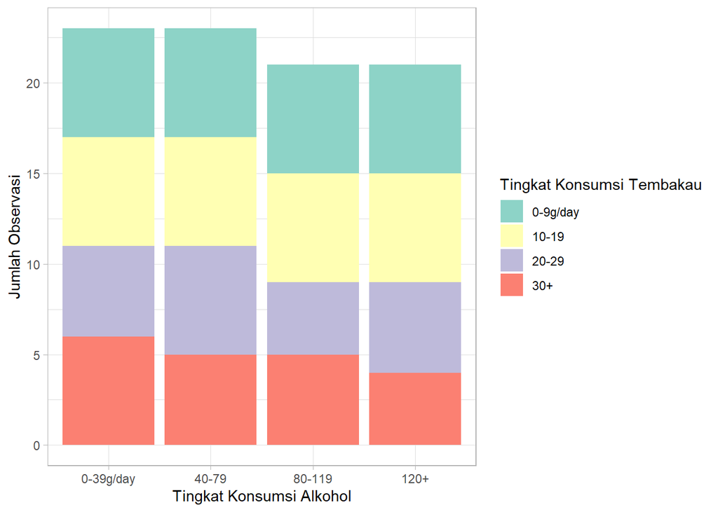

```r
ggplot(data=esoph,
   mapping=aes(x=alcgp, fill=as.factor(tobgp)))+
  geom_bar(position = "stack", stat="count")+

  labs(x="Tingkat Konsumsi Alkohol", fill="Tingkat Konsumsi Tembakau",
       y="Jumlah Observasi")+
  scale_fill_brewer(palette="Set3")+
  theme_light()
```

Berwarna Ungu dengan 20-29 batang per hari : tingginya bertambah dari 5 ke sekitar 10 artinya dalam tiap kelompok konsumsi alkohol adalah sekitar 5 lagi keatas untuk yang merokok lebih dari 20 batang per hari

Berwarna kuning dengan 10-19 batang per hari : tingginya mencapai lebih dari 15. Artinya terdapat tambahan sekitar 5-7 orang yang merokok 10-19 batang per hari

## 0.7 MAP

### 0.7.1 DATA SPASIAL

```r
#Import Data
library(readxl)
library(sf)
data.spasial <- read_xlsx("C:/Users/Fanndry/Documents/output_datashpsulut1.xlsx",sheet = 1)
head(data.spasial)
```

```
## # A tibble: 6 × 8
##   NAME_1          ID_2 NAME_2       TYPE_2 ENGTYPE_2 Longitude Latitude geometry
##   <chr>          <dbl> <chr>        <chr>  <chr>         <dbl>    <dbl> <lgl>
## 1 Sulawesi Utara   372 Bitung       Kotam… Municipa…      125.    1.48  NA
## 2 Sulawesi Utara   373 Bolaang Mon… Kabup… Regency        124.    0.659 NA
## 3 Sulawesi Utara   374 Kepulauan S… Kabup… Regency        126.    3.28  NA
## 4 Sulawesi Utara   375 Manado       Kotam… Municipa…      125.    1.52  NA
## 5 Sulawesi Utara   376 Minahasa Se… Kabup… Regency        125.    1.06  NA
## 6 Sulawesi Utara   377 Minahasa Ut… Kabup… Regency        125.    1.49  NA
```

```r
shp.Provsulut<- read_sf("C:/Users/Fanndry/Documents/SULUT/Export_Output_2.dbf")
shp.Provsulut
```

```
## Simple feature collection with 9 features and 7 fields
## Geometry type: MULTIPOLYGON
## Dimension:     XY
## Bounding box:  xmin: 123.1139 ymin: 0.291731 xmax: 127.1637 ymax: 5.5662
## Geodetic CRS:  WGS 84
## # A tibble: 9 × 8
##   NAME_1          ID_2 NAME_2                TYPE_2 ENGTYPE_2 Longitude Latitude
##   <chr>          <dbl> <chr>                 <chr>  <chr>         <dbl>    <dbl>
## 1 Sulawesi Utara   372 Bitung                Kotam… Municipa…      125.    1.48
## 2 Sulawesi Utara   373 Bolaang Mongondow     Kabup… Regency        124.    0.659
## 3 Sulawesi Utara   374 Kepulauan Sangihe Ta… Kabup… Regency        126.    3.28
## 4 Sulawesi Utara   375 Manado                Kotam… Municipa…      125.    1.52
## 5 Sulawesi Utara   376 Minahasa Selatan      Kabup… Regency        125.    1.06
## 6 Sulawesi Utara   377 Minahasa Utara        Kabup… Regency        125.    1.49
## 7 Sulawesi Utara   378 Minahasa              Kabup… Regency        125.    1.24
## 8 Sulawesi Utara   379 Sangihe Talaud        Kabup… Regency        127.    4.23
## 9 Sulawesi Utara   380 Tomohon               Kabup… Regency        125.    1.32
## # ℹ 1 more variable: geometry <MULTIPOLYGON [°]>
```

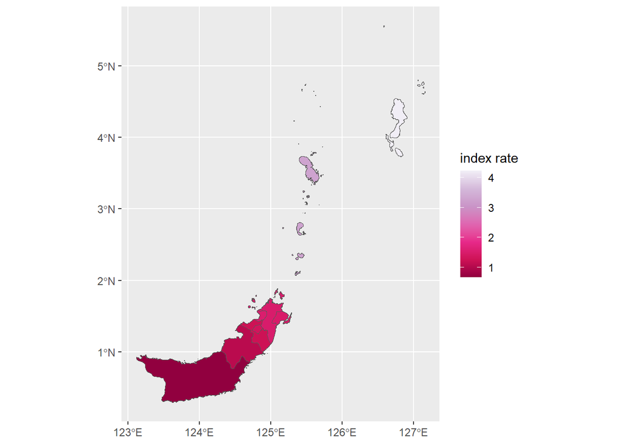

```r
#menggabungkn data

# Import library yang diperlukan
library(sf)
library(dplyr)  # Pastikan library dplyr digunakan untuk left_join

gabung.Provsulut<- left_join(shp.Provsulut,data.spasial,by="ID_2",relationship = "many-to-many")

plot.Provsulut<- ggplot(data = gabung.Provsulut)+
  geom_sf(aes(fill = Latitude.x))+
  scale_fill_distiller("index rate", palette = "PuRd")
plot.Provsulut
```